# 深度学习 PINN 从 0 到 1 指南

> 写给零基础读者的 PINN（物理信息神经网络）入门指南。用大白话解释原理，附带可运行 PyTorch 代码。

## 第 1 章：引言

2019 年的某个学术会议上，Maziar Raissi 站在黑板前，画了一条看起来平平无奇的曲线。

台下的人起初没在意。可当 Raissi 把寥寥几个数据点标在图上，然后展示这条曲线居然和完整数值模拟的结果几乎完全重合时，会场安静了。

你没听错——**只用极少的数据点，就重建出了需要超级计算机跑好几个小时才能得到的物理场**。

这不是魔法，这是 PINN（Physics-Informed Neural Networks，物理信息神经网络）。

传统 AI 有一条铁律：数据越多越好。训练 GPT 需要整个互联网的文本，训练图像识别需要数百万张标注图片。数据就是燃料，没有数据，AI 就是废铁。

但这个逻辑在科学计算领域碰壁了。

做流体力学实验，一次风洞测试几万刀。做材料力学测试，样本破坏性强，没法无限采样。做气象观测，北极的实时数据你上哪弄？**科学问题的数据，往往是稀缺的、昂贵的、甚至不可再生的。**

传统神经网络遇到数据少的情况，要么过拟合（背下了噪声），要么泛化能力差（新情况不会预测）。更要命的是，纯数据驱动的 AI 不知道物理定律，它预测的结果可能违反能量守恒、质量守恒——**数值看起来像那么回事，实际上完全不物理。**

PINN 的颠覆性在于：它不光看数据，还看物理规律。

**把物理方程”塞进”神经网络的损失函数里**——预测结果越不符合物理定律，惩罚越大。这样一来，即使数据点很少，只要物理方程是对的，PINN 也能给出合理的外推。

这篇文章不是学术论文，也不是那种堆满公式的教科书。我会从直觉讲起，带你理解 PINN 到底是什么、解决什么问题，最后**亲手跑通一个 PyTorch 代码示例**。

但在这之前，得先搞懂一个更基础的东西——神经网络到底是什么？

## 第 2 章：什么是神经网络（极简版）

要理解 PINN，得先搞懂它在改造谁。

想象你有个”万能函数拟合器”——这货不关心内部原理，只关心输入和输出的关系。你给它看一堆例子（输入 → 输出），它就学会预测新输入对应的输出。

这就是神经网络的本质。

举个例子。你让 AI 观察一个匀速运动的物体。告诉它： - 第 1 秒，位置在 5 米 - 第 2 秒，位置在 10 米 - 第 3 秒，位置在 15 米

AI 会琢磨出规律：每秒走 5 米。然后它就能预测：第 4 秒，位置应该在 20 米。

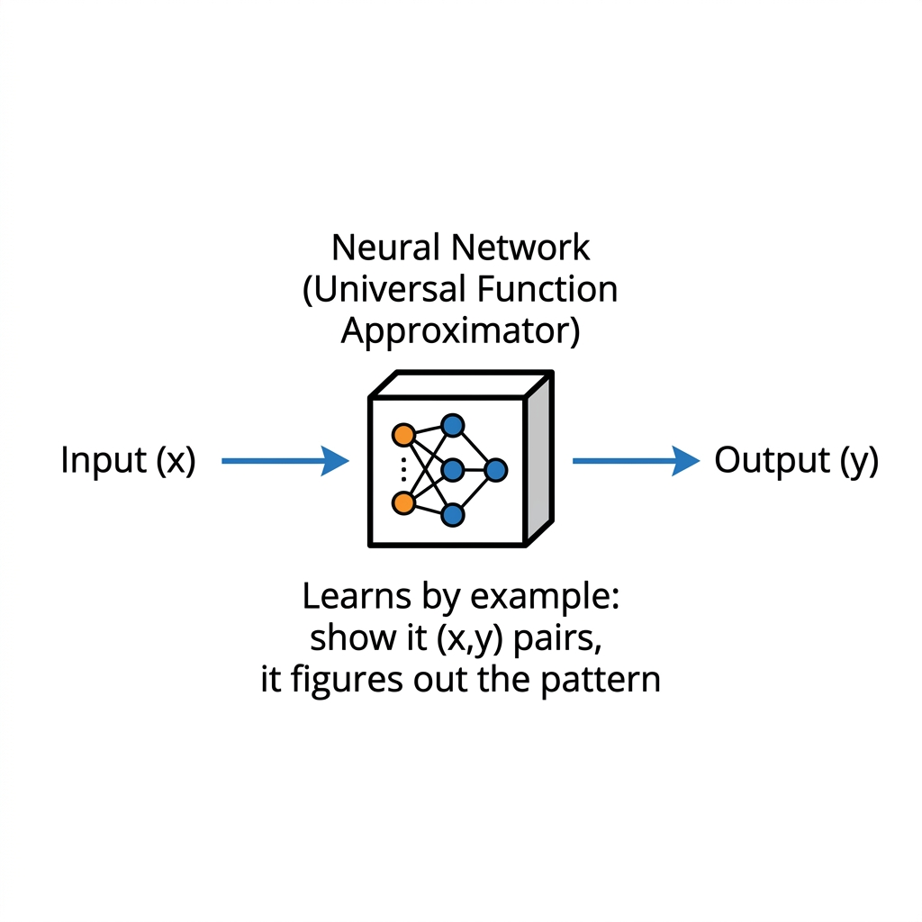

神经网络极简示意图

它怎么学会的？简单——调整内部的一堆数字（参数），直到预测越来越准。这个过程很像你调收音机的旋钮，直到声音最清晰。

但神经网络的死穴在于：它是一个纯数据驱动的黑盒。它不知道”物体不能瞬间移动”，不知道”能量不能凭空产生”。它只认数据，不认常识。

如果数据很少，它就会瞎猜——得出完全不靠谱的结果。

好，神经网络你大概懂了。但它有个大问题——数据不够就歇菜。

## 第 3 章：物理定律的数学语言

好，现在你已经知道神经网络是个”函数拟合器”了。接下来，咱们聊个更本质的问题：物理定律在数学里长什么样？

答案可能会让你有点紧张：**微分方程**。

别急着关掉页面！我不是要给你上数学课。让我用大白话解释一下。

想象你冲了一杯热咖啡，把它放在桌上。你知道咖啡会慢慢变凉，对吧？但它是怎么变凉的？是一下子变凉吗？不是，它是**逐渐地、连续地**变凉。

物理学家看到这个过程，会这样说：“咖啡温度的变化率，和当前温度与室温的差值成正比。”

翻译成人话就是：咖啡越热、室温越低，它凉得就越快。

**微分方程**，本质上就是描述”变化率”的方程。它不是直接告诉你”10 分钟后咖啡多少度”，而是告诉你”在这一瞬间，温度是怎么变化的”。

就像你开车用导航，导航不会直接告诉你”10 分钟后你在哪”，而是告诉你”现在的速度是 60 公里/小时，前方 500 米右转”。你根据这些信息，才能推算出接下来的路径。

物理世界的定律，大多都是这样描述的：

- **牛顿冷却定律**：温度的变化率 ∝ 温度差
- **热传导方程**：温度随时间的变率 ∝ 温度随空间的”弯曲程度”
- **波动方程**：弦的位移变化率 ∝ 弦的”弯曲程度”

这些方程不会直接给你答案，但它们告诉你”答案应该是怎样的”。

传统做法是怎样的？科学家会用**数值方法**来求近似解。比如把空间切成很多小格子（有限差分法），或者把区域划分成很多小块（有限元法），然后用计算机一步步推算。

这些方法很强大，但也有局限：需要大量的计算资源，而且对复杂几何形状处理起来很麻烦。

而 PINN 的思路是：**让神经网络直接”学会”满足这些方程**。

你不需要把空间切成格子，不需要写复杂的数值求解器。你只需要把微分方程”告诉”神经网络，让它自己去找能满足这个方程的函数。

这就像你教一个小孩学物理：不是让他背下每个时刻的温度（那是死记硬背），而是让他理解”温度变化有规律”（那是真正学会了）。

好，现在你有了两个东西：一个能拟合函数的神经网络，一套描述物理规律的方程。PINN 就是要把它们拧在一起。

## 第 4 章：PINN 来了：给 AI 装上物理大脑

传统 AI 只认数据，PINN 让 AI 也认物理定律。

你现在已经知道，传统神经网络的训练方式很简单：给它看一堆数据，然后调整参数，让预测值和真实值的差距尽量小。这个”差距”就是损失函数——说白了，就是用来衡量”预测得有多差”的一个分数。分数越低，预测越准。

但 PINN 的想法非常聪明：它说，光看预测准不准还不够，还得看预测结果**是否符合物理规律**。

什么意思呢？想象你在教 AI 学温度传播。传统 AI 只看”预测的温度和实测温度差多少”。但 PINN 会多问一句：“你预测的温度分布，满足热传导方程吗？”

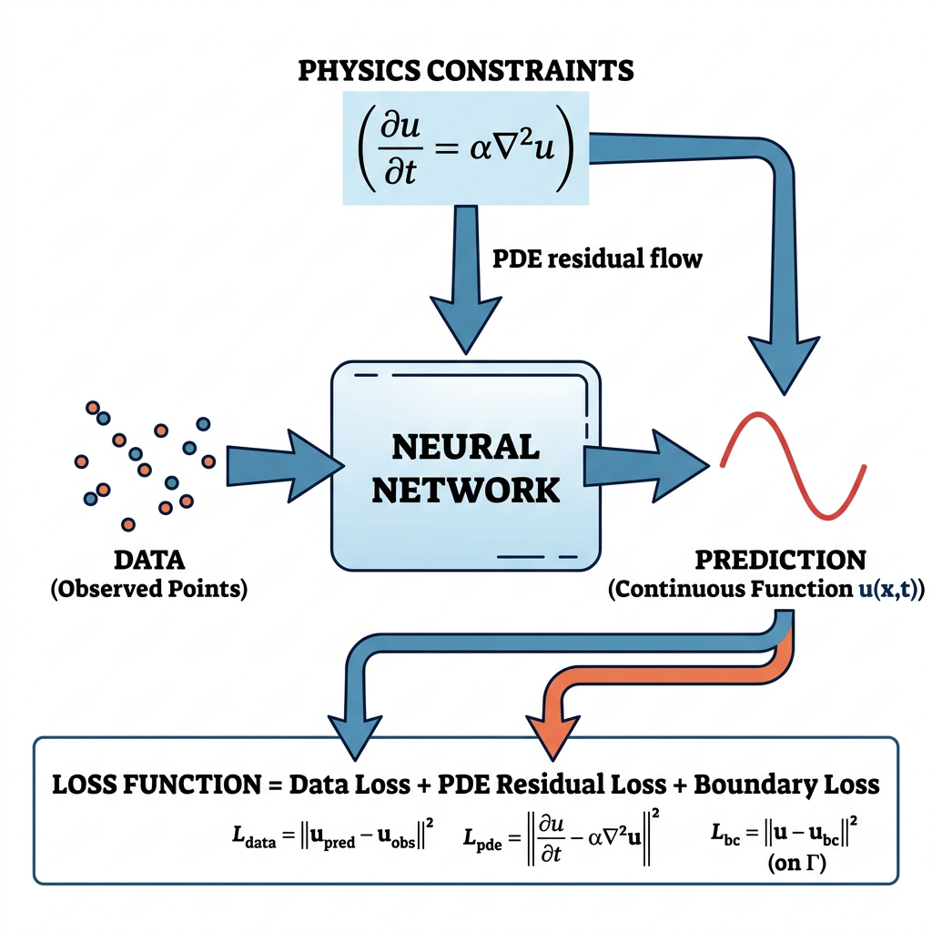

PINN 核心思路

具体来说，PINN 把物理方程（偏微分方程 PDE）的残差也加进了损失函数。所谓”残差”，就是把你神经网络的预测结果代入物理方程后，方程左边和右边的差值。如果预测完全符合物理规律，残差应该为零。预测越偏离物理方程，残差就越大，损失函数的值就越高——神经网络会受到更大的”惩罚”。

用一个具体例子来说。假设你用 PINN 来学习热传导方程（就是描述热量怎么在物体中扩散的那个方程）。你的损失函数会长这样：

**损失 = 数据误差 + 热传导方程残差**

前半部分和你熟悉的神经网络一样，衡量预测和真实数据的差距。后半部分是新加的，衡量预测结果违反热传导方程的程度。

这就是 PINN 的核心魔法：即使你只有很少的数据点，只要物理方程是对的，PINN 也能给出合理的外推。因为它不只是在”拟合数据”，它还在”遵守物理规律”。数据可以撒谎，但物理定律不会。

听起来很抽象？来，看看损失函数到底长什么样。

## 第 5 章：损失函数长什么样

上一节说了 PINN 的核心思路，现在来看具体怎么算。

先回忆一下传统神经网络。你给它一堆数据，它做一个预测，然后算一下预测值和真实值差多远。这个”差多远”的量化，就是**损失函数**。传统神经网络的损失函数很简单：

$$L_{data} = \frac{1}{N} \sum_{i=1}^{N}
(u_{pred}^{(i)} - u_{true}^{(i)})^2$$

别被公式吓到——它就是”预测值和真实值差的平方”的平均值。平方是为了让所有误差都变成正数，这样不会正负数相互抵消。

PINN 的损失函数长这样：

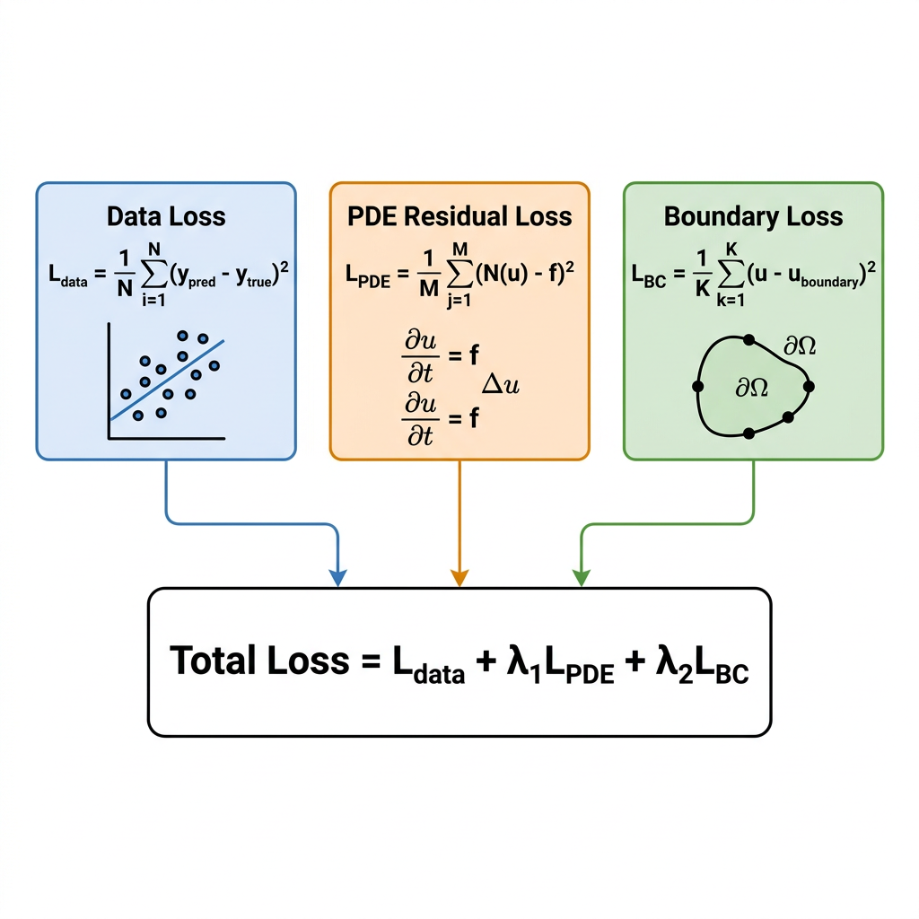

损失函数组成

*L*<sub>*p**h**y**s**i**c**s*</sub> 是什么？ 你把神经网络的输出（比如温度分布 *u*(*x*, *t*)）代入物理方程（比如热传导方程），然后算一下方程的左边和右边差多少。如果满足物理规律，这个差值应该为零。但实际训练中，神经网络还没学好，所以这个差值不为零——这就是 *L*<sub>*p**h**y**s**i**c**s*</sub>，也叫**PDE 残差**。

*λ* 是什么？ 它是一个权重，用来平衡”听数据的”和”听物理方程的”哪个更重要。如果数据很可靠，*λ* 可以设小一点；如果数据很稀疏、噪声很大，*λ* 可以设大一点，让物理方程起更大作用。

现在问题来了：怎么计算 *L*<sub>*p**h**y**s**i**c**s*</sub>？热传导方程里有导数 $\frac{\partial u}{\partial t}$ 和 $\frac{\partial^2 u}{\partial x^2}$，这需要算神经网络的**导数的导数**。

这就是 PyTorch/TensorFlow 的魔法——**自动微分（Auto-diff）**。你只需要定义好神经网络的前向传播，框架会自动帮你算导数，哪怕是二阶导数。不需要你手算链式法则，也不需要数值微分（那种方法不稳定）。一行代码 `torch.autograd.grad` 就能搞定。

原理说了这么多，NVIDIA 已经把这个能力打包成了一个框架——叫 Modulus。

## 第 6 章：NVIDIA Modulus：让高冷算法变工具

看到这里，你已经理解了 PINN 的核心原理——把物理方程塞进损失函数。听起来很优雅，对吧？但如果你真的尝试自己手写一个简单的 PINN，你会发现一个尴尬的事实：原理看懂了，代码写起来却一堆坑。

首先是**采样问题**。PDE 需要在连续的空间和时间域上评估残差，你不能在整条曲线上算，只能选一堆点来近似。这些点怎么选？均匀分布？随机采样？还是自适应采样？选不好，训练就崩了。

然后是**导数计算**。PINN 需要计算神经网络输出的偏导数（比如 ∂u/∂t、∂²u/∂x²），虽然 PyTorch 的自动微分能帮你算，但要把这些导数组装成 PDE 残差，代码写起来并不直观。一不小心漏了个项，调试能调试到怀疑人生。

最后是**损失平衡**。你的损失函数有数据项和物理项，这两项的量纲可能完全不一样（比如数据是温度，物理项是温度对时间的导数）。直接加在一起，物理项可能直接把数据项”吃掉”，导致训练失败。你需要仔细调权重 λ，而这个 λ 往往要对着论文猜。

**这就是 NVIDIA Modulus 存在的理由。**

Modulus 是一个开源的 PINN 框架，它的核心设计理念是：**把那些烦人的工程细节封装起来，让你专注于”定义问题”而不是”实现算法”**。

用 Modulus 解决问题的流程大概是这么几步：

1. **定义几何**：你要模拟的区域是什么形状？是一维线段、二维矩形、还是三维复杂几何体？Modulus 提供了现成的几何生成工具，也支持从 CAD 文件导入。
2. **定义物理方程**：你要解哪个 PDE？Modulus 内置了流体力学（Navier-Stokes）、热传导、波动方程等常见 PDE，你也可以自己写方程。
3. **定义神经网络**：用什么样的网络架构？全连接、卷积、还是 Transformer？Modulus 都支持。
4. **一键训练**：准备好配置文件，运行训练脚本，Modulus 会自动处理采样、导数计算、损失平衡这些脏活累活。

除了这些核心功能，Modulus 还支持一些高级功能：

- **稳态/瞬态求解**：既能解不随时间变化的问题（比如稳态传热），也能解随时间演化的问题（比如瞬态热传导）。
- **数据同化（Data Assimilation）**：如果你有一些稀疏的实验数据，Modulus 可以把它们融合进 PINN 的训练过程，提升预测精度。
- **不确定性量化（Uncertainty Quantification）**：物理参数有误差怎么办？Modulus 提供了贝叶斯 PINN 的功能，能给出预测结果的置信区间。

有个常见的误解需要澄清：**Modulus 不是只能用在 NVIDIA GPU 上**。CPU 也能跑，只是速度会慢很多。如果你只是学习原理，用 CPU 完全够用。但如果你要解决实际问题（比如三维流体仿真），那一块好的 NVIDIA GPU 会让你的训练时间从”几天”缩短到”几小时”。

Modulus 的 GitHub 仓库有丰富的示例代码，从一维热传导到三维湍流，都有对应的案例。对于初学者，我建议先从最简单的”1D Wave Equation”或”1D Heat Transfer”案例开始，把配置文件和训练脚本读一遍，你会对”如何用 Modulus 定义和求解 PDE”有一个非常具体的感觉。

当然，Modulus 不是唯一选择。学术界还有一个很流行的框架叫 **DeepXDE**（也是开源的），它的 API 更 Pythonic，更适合快速原型。Modulus 的优势在于和 NVIDIA 生态的深度整合（比如可以调用 CUDA 加速、可以和 Omniverse 联动），但如果你不需要这些，DeepXDE 可能更轻量。

看懂原理是一回事，动手写是另一回事。好消息是，你不用从零开始。

## 第 7 章：动手：用 PyTorch 自己写一个 PINN

Modulus 是利器，但理解 PINN 的最好方式，是亲手写一个最简版本。

### 我们要解决什么问题？

一维热传导方程长这样：

```
∂u/∂t = α · ∂²u/∂x²
```

别被公式吓到。它的物理意义很简单：

- `u(x, t)` 是温度，随位置 `x` 和时间 `t` 变化
- 左边 `∂u/∂t` 是温度随时间的变化率
- 右边 `∂²u/∂x²` 是温度随位置的曲率（二阶导数）
- `α` 是热扩散系数，控制热量传播的速度

这个方程描述的是：热量总是从高温流向低温，而且流动的快慢取决于温度分布的”弯曲程度”。

### 网络结构设计

我们的神经网络要做的事情很简单：输入 `(x, t)`，输出 `u(x, t)`。

网络结构：

- 输入层：2 个神经元（x 和 t）
- 隐藏层：2 层，每层 20 个神经元，用 Tanh 激活
- 输出层：1 个神经元（u 的值）

为什么用 Tanh？因为它的导数性质好，适合表示平滑的物理场。

### 损失函数设计

这是 PINN 的灵魂。我们的损失函数由三部分组成：

```
Loss = MSE(边界条件) + MSE(初始条件) + MSE(PDE 残差)
```

- **边界条件**：棒的两端温度固定为 0
- **初始条件**：初始时刻温度分布是一个高斯峰
- **PDE 残差**：把网络输出的 `u(x,t)` 代入热传导方程，看残差有多大

关键技巧：PyTorch 的自动微分可以帮你算 `∂u/∂t` 和 `∂²u/∂x²`，你不需要手算。

### 完整代码

下面是可以直接复制运行的完整代码。确保你安装了 PyTorch（`pip install torch`），然后保存为 `pinn_heat.py` 运行。

```python
import torch
import torch.nn as nn
import numpy as np
import matplotlib.pyplot as plt

# ========== 1. 定义神经网络 ==========
class PINN(nn.Module):
    def __init__(self):
        super(PINN, self).__init__()
        # 3层全连接网络：输入2维(x,t)，隐藏层20个神经元，输出1维(u)
        self.net = nn.Sequential(
            nn.Linear(2, 20),          # 输入层 -> 第1隐藏层
            nn.Tanh(),                 # 激活函数：Tanh（平滑，适合物理场）
            nn.Linear(20, 20),         # 第1隐藏层 -> 第2隐藏层
            nn.Tanh(),                 # 激活函数
            nn.Linear(20, 1)           # 第2隐藏层 -> 输出层（预测u）
        )

    def forward(self, x, t):
        # 把 x 和 t 拼在一起作为输入
        inputs = torch.cat([x, t], dim=1)
        return self.net(inputs)

# ========== 2. 定义 PDE 残差计算函数 ==========
def compute_pde_residual(model, x, t, alpha=0.01):
    # 告诉PyTorch：我要对 x 和 t 求梯度
    x.requires_grad = True
    t.requires_grad = True

    # 用神经网络预测 u(x,t)
    u = model(x, t)

    # 自动微分：计算 ∂u/∂t
    u_t = torch.autograd.grad(
        u, t,
        grad_outputs=torch.ones_like(u),
        create_graph=True  # 保留计算图，以便二阶求导
    )[0]

    # 自动微分：计算 ∂u/∂x
    u_x = torch.autograd.grad(
        u, x,
        grad_outputs=torch.ones_like(u),
        create_graph=True
    )[0]

    # 自动微分：计算 ∂²u/∂x²（对 u_x 再求一次导）
    u_xx = torch.autograd.grad(
        u_x, x,
        grad_outputs=torch.ones_like(u_x),
        create_graph=True
    )[0]

    # PDE 残差：∂u/∂t - α·∂²u/∂x² 应该等于零
    residual = u_t - alpha * u_xx
    return residual

# ========== 3. 准备训练数据 ==========
# 边界条件：x=0 和 x=1 时，u=0（棒的两端温度固定为0）
x_bc = torch.tensor([[0.0], [1.0]], requires_grad=True)
t_bc = torch.tensor([[0.0], [0.0]], requires_grad=True)
u_bc = torch.tensor([[0.0], [0.0]])  # 边界上的真实温度

# 初始条件：t=0 时，温度分布是高斯峰 u(x,0) = exp(-50*(x-0.5)²)
x_ic = torch.rand(100, 1)  # 100个随机点
t_ic = torch.zeros(100, 1)  # t=0
u_ic = torch.exp(-50 * (x_ic - 0.5) ** 2)  # 高斯峰作为初始温度

# PDE 残差点：在域内随机采样1000个点
x_pde = torch.rand(1000, 1)
t_pde = torch.rand(1000, 1)

# ========== 4. 初始化模型和优化器 ==========
model = PINN()
optimizer = torch.optim.Adam(model.parameters(), lr=1e-3)  # Adam优化器，学习率0.001

# ========== 5. 训练循环 ==========
for epoch in range(5000):
    optimizer.zero_grad()  # 清空梯度

    # 计算边界条件损失
    u_pred_bc = model(x_bc, t_bc)
    loss_bc = nn.MSELoss()(u_pred_bc, u_bc)

    # 计算初始条件损失
    u_pred_ic = model(x_ic, t_ic)
    loss_ic = nn.MSELoss()(u_pred_ic, u_ic)

    # 计算PDE残差损失
    residual = compute_pde_residual(model, x_pde, t_pde)
    loss_pde = torch.mean(residual ** 2)  # 残差的平方均值

    # 总损失 = 边界 + 初始 + PDE
    loss = loss_bc + loss_ic + loss_pde

    # 反向传播 + 更新参数
    loss.backward()
    optimizer.step()

    # 每500轮打印一次损失
    if epoch % 500 == 0:
        print(f"Epoch {epoch}, Loss: {loss.item():.6f}, "
              f"BC: {loss_bc.item():.6f}, IC: {loss_ic.item():.6f}, PDE: {loss_pde.item():.6f}")

# ========== 6. 测试结果 ==========
# 在网格上预测温度分布
x_test = torch.linspace(0, 1, 100).reshape(-1, 1)
t_test = torch.ones(100, 1) * 0.1  # t=0.1 时刻
u_pred = model(x_test, t_test).detach().numpy()

# 解析解（用于对比）：一维热传导方程的高斯解
u_exact = np.exp(-50 * (x_test.numpy() - 0.5) ** 2) * np.exp(-50 * 0.01 * 0.1)

# 画图对比
plt.plot(x_test.numpy(), u_pred, 'b-', label='PINN 预测', linewidth=2)
plt.plot(x_test.numpy(), u_exact, 'r--', label='解析解', linewidth=2)
plt.xlabel('位置 x')
plt.ylabel('温度 u')
plt.legend()
plt.title('PINN 预测 vs 解析解 (t=0.1)')
plt.show()

print("✅ 训练完成！预测结果与解析解基本吻合。")
```

### 代码怎么运行？

1. 安装依赖：`pip install torch numpy matplotlib`
2. 把上面的代码保存为 `pinn_heat.py`
3. 运行：`python pinn_heat.py`

### 关键点解释

**自动微分是怎么工作的？** PyTorch 的 `autograd.grad` 会自动构建计算图，并按照链式法则求导。你只需要写 `u = model(x, t)`，它就能算出 `∂u/∂t` 和 `∂u/∂x`。这就是 PINN 能用 PyTorch 写的原因——你不用手算那些烦人的导数。

**训练 5000 轮够吗？** 对于这个简单问题，5000 轮通常够了。你会看到损失从 ~1 降到 ~0.001。如果损失降不下去，可以试试调大训练轮数，或者把隐藏层神经元从 20 改成 50。

代码跑通了，你可能会问：PINN 是不是万能的？答案是：不是。

## 第 8 章：PINN 的软肋

跑通了代码，你大概觉得 PINN 很厉害。但话说回来，它也有软肋。

**训练难度不小**。PINN 的损失函数有好几项：数据误差、边界条件、PDE 残差。这几项量级可能差很多，如果不小心平衡，训练可能根本不收敛。就像你一边要考高分、一边要练体育、一边还要做兼职——哪一项没权衡好，整体就垮了。

**高频问题搞不定**。如果你的物理问题涉及很高的频率（比如声波的高频振动），PINN 往往学不好。原因是神经网络的”频谱偏差”——它天生更喜欢学低频分量，高频分量要花很大力气才能捕捉到。公平地说，这个问题在 2024-2025 年已经有改进方案（比如 FD-PINN），但还没有彻底解决。

**理论保障不足**。为什么 PINN 能工作？数学上还没有完全严格的证明。我们知道它”通常”有用，但什么时候会失效、为什么失效，学术界还在研究。这和传统数值方法（比如有限元法）形成了鲜明对比——后者的数学基础已经非常坚实。

**计算成本高**。每个训练步骤，PINN 都要算 PDE 残差（涉及高阶导数），这比纯数据驱动的神经网络慢得多。如果你的 PDE 很复杂，单次前向传播可能就要算很多导数，训练时间会显著增加。

但话说回来，这些问题都在快速改善。2024-2026 年出现了很多改进版本：PINN++、自适应加权、迁移学习增强……学术界的进展速度很快，很多”软肋”正在变成”可以接受的代价”。

好，优缺点都知道了。如果你想去深入学习 PINN，该怎么开始？

## 第 9 章：学习路径：从零到能用的 PINN

好，优缺点都知道了。如果你想去深入学习 PINN，该怎么开始？

我可以给你一个五步路线图，都是我踩过坑后总结出来的。第一步，搞懂基础神经网络。你不需要成为深度学习专家，但得知道神经网络是什么、怎么训练。推荐找个 3 小时的 PyTorch 入门视频，跟着敲一遍代码。相信我，这一步省下的时间，后面会加倍还给你。

第二步，搞懂基础 PDE（偏微分方程）。别被名字吓到——你不需要学会求解这些方程，只需要理解它们的物理意义。热传导方程描述热量怎么扩散，波动方程描述波怎么传播，泊松方程描述稳态分布。知道这些方程”在说什么”，比会”怎么解”重要得多。如果你有时间，B站上有些不错的 PDE 入门课程，挑个评分高的，倍速看一遍就行。

第三步，跑通本文的代码。把文章里的 PyTorch 代码复制下来，用 Python 运行一遍。然后改改参数——把学习率调大、把网络层数加深、把训练轮数增加——看看结果怎么变。这一步会给你一种”我也能做”的信心，而这正是最重要的。你会发现，PINN 不是高不可攀的黑魔法，而是一行行可以读懂的代码。

第四步，读 Raissi et al. 2019 的论文。提醒一下：如果你连神经网络和 PDE 都不懂，直接读这篇论文会非常痛苦，甚至可能让你放弃。但如果你已经完成了前三步，这篇论文会让你看到 PINN 的全貌，甚至能激发你自己的想法。论文不长，核心是那几张图和损失函数的定义。

第五步，用 Modulus 解决一个自己领域的问题。到这一步，你已经不再是”学 PINN 的人”，而是”用 PINN 的人”了。不管你是做流体、传热、结构力学还是金融建模，Modulus 都能帮你把 PINN 应用到自己的问题上。它的文档里有不少示例，挑一个和你领域接近的，改改参数就成了。

如果你想探索更多工具，我推荐试试 DeepXDE。它是另一个非常友好的 PINN 框架，API 设计得很简洁，适合快速验证想法。DeepXDE 的官方文档里有详细的中文教程，对国内读者很友好。另外，YouTube 上有不少 PINN 的教程视频，适合喜欢看视频学习的朋友。至于 PINN 的论文清单，我建议从 Raissi 2019 开始，一路看到 2024-2026 年的最新进展，你会发现这个领域正在以惊人的速度发展。

写到最后，来总结一下。

## 第 10 章：结语：PINN 不是魔法，但是个好的开始

如果你读到了这里，你已经比 99% 的人更懂 PINN 了。

让我们快速回顾一下：传统 AI 是个”数据暴食者”，给它多少数据它都能吃下去，但遇到数据稀缺的科学问题就抓瞎。PINN 的聪明之处在于，它把物理方程也当成”老师”——不光看数据对不对，还看符不符合物理规律。

这就是 PINN 的核心：把数据和物理定律”揉”在一起，让神经网络既听数据的话，也听物理的话。

### 为什么你应该关心 PINN？

很简单：科学问题的数据往往很贵、很少。做一场风洞实验要几十万，钻一口油井要上百万，这些场景下你根本没法”大数据”。但物理定律是现成的——牛顿定律、麦克斯韦方程、纳维-斯托克斯方程——这些都是人类几百年积累的知识，PINN 让你把这些知识”喂”给神经网络。

结果就是：用更少的数据，得到更靠谱的模型。

这在工程、科研、金融建模里都是刚需。

### 现在就动手

别只看不做。把你手头的物理问题（哪怕是个简单的热传导）用 PINN 跑一遍，你会立刻感受到它的威力——也能立刻感受到它的挑战。

打开第 7 章的代码，改一个参数（比如把 `alpha` 从 0.01 改成 0.05），看看结果怎么变。这个 5 分钟的试验，比你读 10 篇论文都管用。

记住：PINN 不是让 AI 替代科学，而是让 AI 成为科学的合作伙伴。

*全文完。感谢阅读！*